# Lab 05 - Halloween Candies & Data Viz Improvement

Zack

2026-10-31

### Load packages

```r
library(tidyverse)
library(ggplot2)
```

# Questioning data visualisations

## Image 4

# Data Visualization for Halloween

Ensure that you have the following two lines of code at the top of `lab-05.Rmd` to make the commands available to you.

```r
library(tidyverse)
library(ggplot2)

# Install that package first
# install.packages("fivethirtyeight")
library(fivethirtyeight)
```

```r
candy_df <- candy_rankings
glimpse(candy_df)
```

```
## Rows: 85
## Columns: 13
## $ competitorname   <chr> "100 Grand", "3 Musketeers", "One dime", "One quarter…
## $ chocolate        <lgl> TRUE, TRUE, FALSE, FALSE, FALSE, TRUE, TRUE, FALSE, F…
## $ fruity           <lgl> FALSE, FALSE, FALSE, FALSE, TRUE, FALSE, FALSE, FALSE…
## $ caramel          <lgl> TRUE, FALSE, FALSE, FALSE, FALSE, FALSE, TRUE, FALSE,…
## $ peanutyalmondy   <lgl> FALSE, FALSE, FALSE, FALSE, FALSE, TRUE, TRUE, TRUE, …
## $ nougat           <lgl> FALSE, TRUE, FALSE, FALSE, FALSE, FALSE, TRUE, FALSE,…
## $ crispedricewafer <lgl> TRUE, FALSE, FALSE, FALSE, FALSE, FALSE, FALSE, FALSE…
## $ hard             <lgl> FALSE, FALSE, FALSE, FALSE, FALSE, FALSE, FALSE, FALS…
## $ bar              <lgl> TRUE, TRUE, FALSE, FALSE, FALSE, TRUE, TRUE, FALSE, F…
## $ pluribus         <lgl> FALSE, FALSE, FALSE, FALSE, FALSE, FALSE, FALSE, TRUE…
## $ sugarpercent     <dbl> 0.732, 0.604, 0.011, 0.011, 0.906, 0.465, 0.604, 0.31…
## $ pricepercent     <dbl> 0.860, 0.511, 0.116, 0.511, 0.511, 0.767, 0.767, 0.51…
## $ winpercent       <dbl> 66.97173, 67.60294, 32.26109, 46.11650, 52.34146, 50.…
```

## Exercise 1

How many observations and variables are in this dataset? Did you identify the type of variables, remember that this detail is crucial to create which kind of data visualization in general.

```r
glimpse(candy_df)
```

```
## Rows: 85
## Columns: 13
## $ competitorname   <chr> "100 Grand", "3 Musketeers", "One dime", "One quarter…
## $ chocolate        <lgl> TRUE, TRUE, FALSE, FALSE, FALSE, TRUE, TRUE, FALSE, F…
## $ fruity           <lgl> FALSE, FALSE, FALSE, FALSE, TRUE, FALSE, FALSE, FALSE…
## $ caramel          <lgl> TRUE, FALSE, FALSE, FALSE, FALSE, FALSE, TRUE, FALSE,…
## $ peanutyalmondy   <lgl> FALSE, FALSE, FALSE, FALSE, FALSE, TRUE, TRUE, TRUE, …
## $ nougat           <lgl> FALSE, TRUE, FALSE, FALSE, FALSE, FALSE, TRUE, FALSE,…
## $ crispedricewafer <lgl> TRUE, FALSE, FALSE, FALSE, FALSE, FALSE, FALSE, FALSE…
## $ hard             <lgl> FALSE, FALSE, FALSE, FALSE, FALSE, FALSE, FALSE, FALS…
## $ bar              <lgl> TRUE, TRUE, FALSE, FALSE, FALSE, TRUE, TRUE, FALSE, F…
## $ pluribus         <lgl> FALSE, FALSE, FALSE, FALSE, FALSE, FALSE, FALSE, TRUE…
## $ sugarpercent     <dbl> 0.732, 0.604, 0.011, 0.011, 0.906, 0.465, 0.604, 0.31…
## $ pricepercent     <dbl> 0.860, 0.511, 0.116, 0.511, 0.511, 0.767, 0.767, 0.51…
## $ winpercent       <dbl> 66.97173, 67.60294, 32.26109, 46.11650, 52.34146, 50.…
```

*Write your comments about results* There are 85 observations, 13 variables. competitorname - categorical chocolate - categorical fruity - categorical caramel - categorical peanutyalmondy - categorical nougat - categorical crispedricewafer - categorical hard - categorical bar - categorical pluribus - categorical surgarpercent - numerical pricepercent - numerical winpercent - numerical

# Data viz - One variable at a time

Just to use the logical variables as categories, run the following code chunk first!

```r
candy_df <- candy_df %>%
  mutate(across(where(is.logical), as_factor))

candy_df
```

```
## # A tibble: 85 × 13
##    competitorname     chocolate fruity caramel peanutyalmondy nougat
##    <chr>              <fct>     <fct>  <fct>   <fct>          <fct>
##  1 100 Grand          TRUE      FALSE  TRUE    FALSE          FALSE
##  2 3 Musketeers       TRUE      FALSE  FALSE   FALSE          TRUE
##  3 One dime           FALSE     FALSE  FALSE   FALSE          FALSE
##  4 One quarter        FALSE     FALSE  FALSE   FALSE          FALSE
##  5 Air Heads          FALSE     TRUE   FALSE   FALSE          FALSE
##  6 Almond Joy         TRUE      FALSE  FALSE   TRUE           FALSE
##  7 Baby Ruth          TRUE      FALSE  TRUE    TRUE           TRUE
##  8 Boston Baked Beans FALSE     FALSE  FALSE   TRUE           FALSE
##  9 Candy Corn         FALSE     FALSE  FALSE   FALSE          FALSE
## 10 Caramel Apple Pops FALSE     TRUE   TRUE    FALSE          FALSE
## # ℹ 75 more rows
## # ℹ 7 more variables: crispedricewafer <fct>, hard <fct>, bar <fct>,
## #   pluribus <fct>, sugarpercent <dbl>, pricepercent <dbl>, winpercent <dbl>
```

## Exercise 2

Complete the following code to get the data viz to represent “how many candies contain caramel via bar plot”. Fill in the blanks, remove the # symbol in front of your code and the execute the code chunk via green play button.

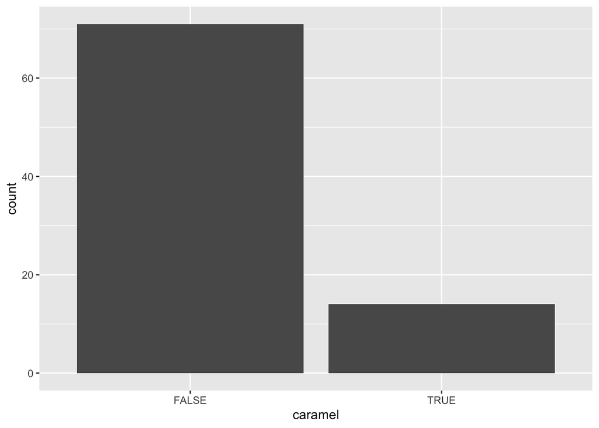

```r
ggplot(candy_rankings, aes(x = caramel)) +
  geom_bar()
```

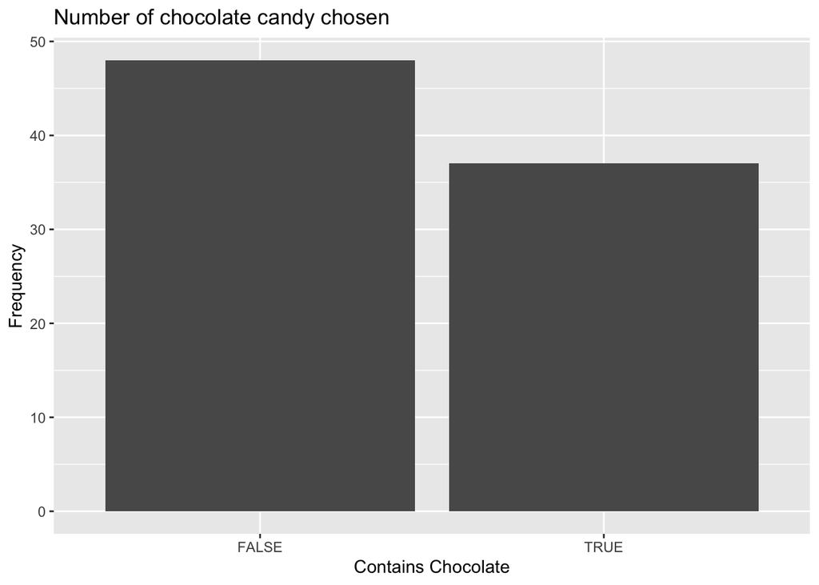

```r
ggplot(candy_rankings, aes(x = chocolate)) +
  geom_bar() +
  labs(
    x = "Contains Chocolate",
    y = "Frequency",
    title = "Number of chocolate candy chosen"
  )
```

There are fewer candy with caramel than all non-caramel ones.

## Exercise 3

Now look at a numerical variable, such as `winpercent`. Create an histogram for this variable using ggplot2 functions below. Include informative x and y labels and a title, as a good practice.

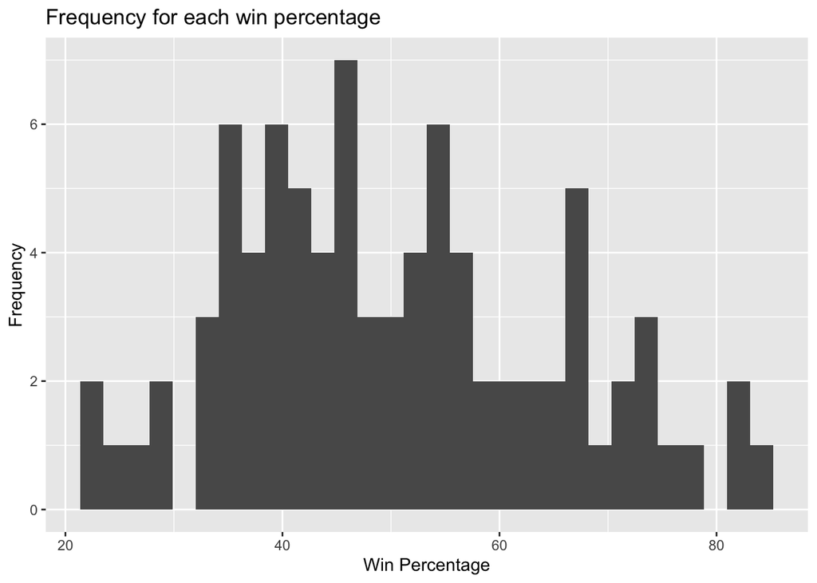

```r
# Your code here
ggplot(candy_rankings, aes(x = winpercent)) +
  geom_histogram() +
  labs(
    x = "Win Percentage",
    y = "Frequency",
    title = "Frequency for each win percentage"
  )
```

# Data viz - more than one variable

## Exercise 4

How about using the both variables; chocolate vs winpercent? Run the following incomplete code snippet to get a faceted visualization.

Fill in the blanks, remove the # symbol in front of your code and the execute the code chunk via green play button.

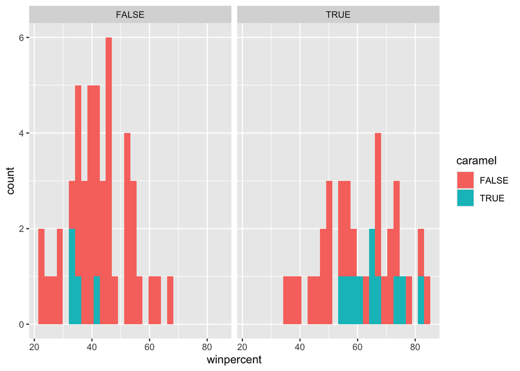

```r
# Your code here
ggplot(candy_df, aes(x = winpercent, fill = caramel)) +
  geom_histogram() +
  facet_wrap(~ chocolate)
```

- Consider adding the `fill = caramel` within the aes() vs. geom_histogram(), what do you get?

## Exercise 5

Create a visualization that examines the relationship between a candy’s win percentage and whether it contains chocolate. Include x and y labels and a title. Describe any relationship you see.

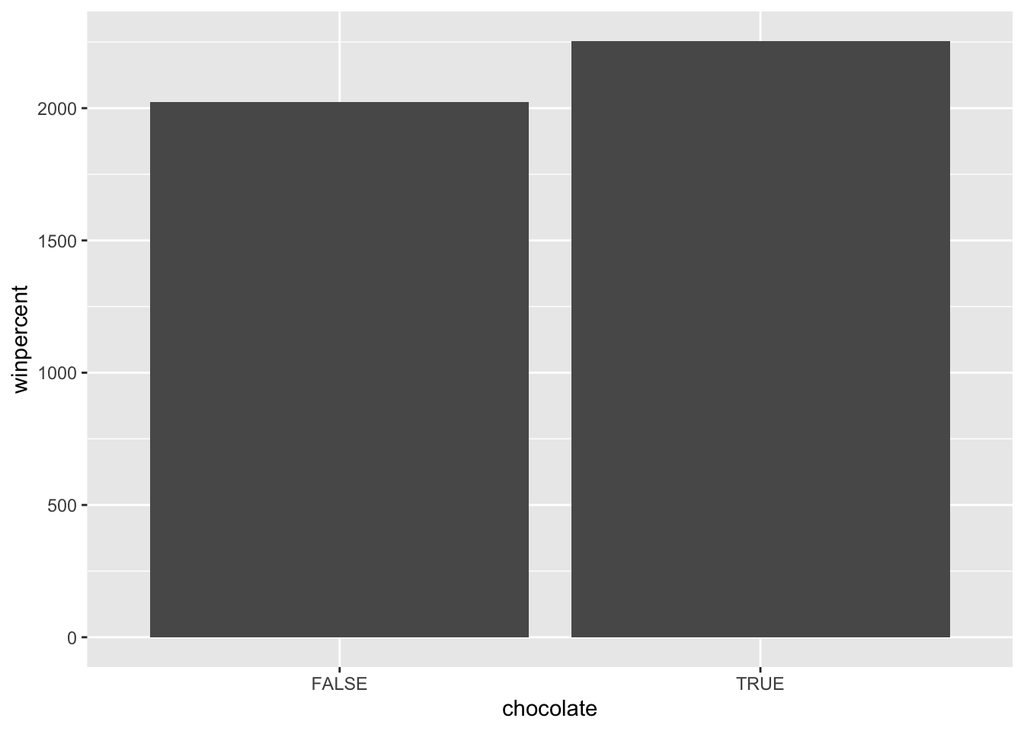

```r
# your code here
ggplot(candy_rankings, aes(x = chocolate, y = winpercent)) +
  geom_col()
```

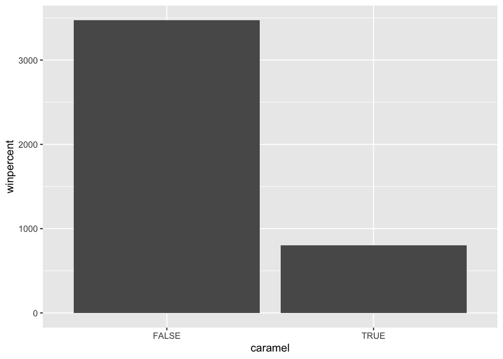

```r
ggplot(candy_rankings, aes(x = caramel, y = winpercent)) +
  geom_col()
```

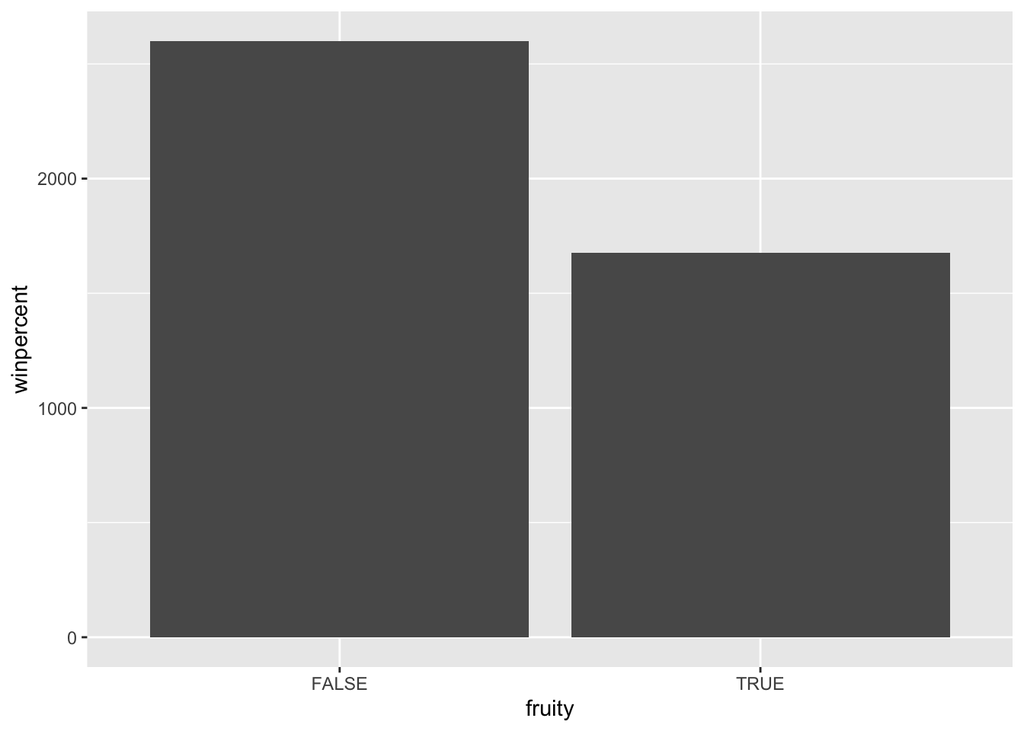

```r
ggplot(candy_rankings, aes(x = fruity, y = winpercent)) +
  geom_col()
```

- Consider the similar pair by replacing chocolate with caramel, fruity and compare their results.
- Also include summary statistics details for this discussion by using the calculation below:

```r
candy_rankings %>%
  group_by(chocolate) %>%
  summarise(
    n = n(),
    mean_win = mean(winpercent),
    median_win = median(winpercent)
  )
```

```
## # A tibble: 2 × 4
##   chocolate     n mean_win median_win
##   <lgl>     <int>    <dbl>      <dbl>
## 1 FALSE        48     42.1       41.6
## 2 TRUE         37     60.9       60.8
```

```r
candy_rankings %>%
  group_by(caramel) %>%
  summarise(
    n = n(),
    mean_win = mean(winpercent),
    median_win = median(winpercent)
  )
```

```
## # A tibble: 2 × 4
##   caramel     n mean_win median_win
##   <lgl>   <int>    <dbl>      <dbl>
## 1 FALSE      71     48.9       46.4
## 2 TRUE       14     57.3       60.2
```

```r
candy_rankings %>%
  group_by(fruity) %>%
  summarise(
    n = n(),
    mean_win = mean(winpercent),
    median_win = median(winpercent)
  )
```

```
## # A tibble: 2 × 4
##   fruity     n mean_win median_win
##   <lgl>  <int>    <dbl>      <dbl>
## 1 FALSE     47     55.3       56.5
## 2 TRUE      38     44.1       43.0
```

## Exercise 6

Do more expensive candies win more often? Make a scatterplot of pricepercent (x) against winpercent (y). Describe their relationship.

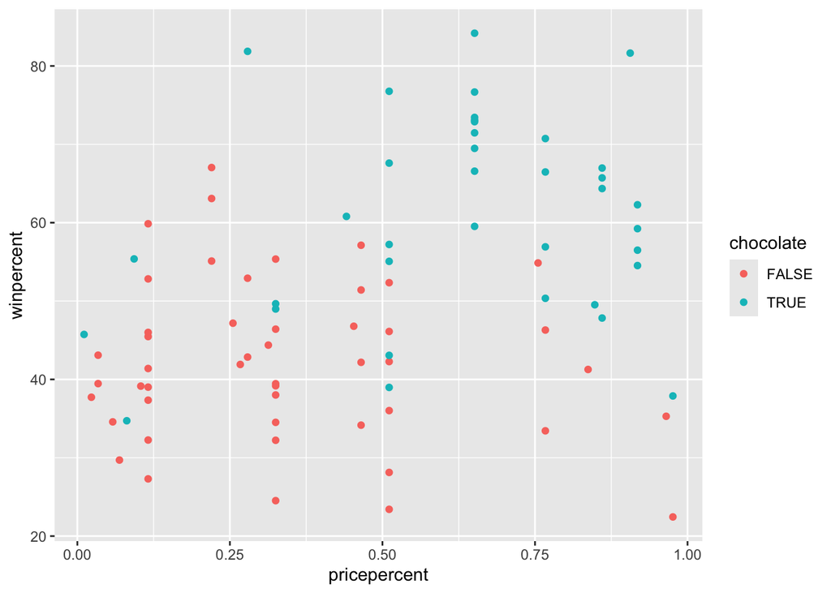

```r
# your code here
ggplot(candy_df, aes(x = pricepercent, y = winpercent, colour = chocolate)) +
  geom_point()
```

- Add `color = chocolate` to add a third variable to the created visualization
- How to facet this by using another categorical variable such as `bar`?

Most candy containing chocolate are in bar form.

Candy containing chocolate has higher win percentages on average, compared to the rest.

There is no obvious correlation between price and win percentage, but candy between 0.5 percent and 0.75 percent have the highest win percentage.

## Exercise 7

Are chocolate candies more likely to be candy bars? Make a filled bar plot with chocolate on the x-axis and fill = bar. Describe what you see.

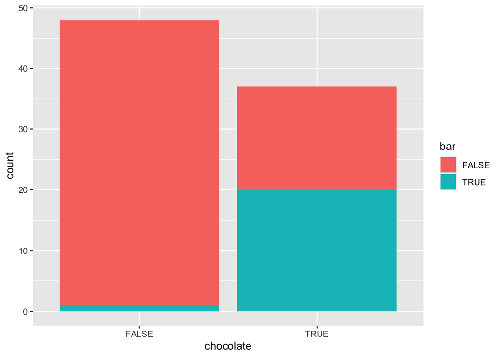

```r
# Your code here
ggplot(candy_df, aes(x = chocolate, fill = bar)) +
  geom_bar()
```

Answer is yes

## Exercise 8

Create a new variable called price per sugar ratio as the division of pricepercent and sugarpercent. Plot it against winpercent, and set the color of all points to blue for the competitors who are not “One dime” or “One quarter”. Include x and y labels and a title. Describe any relationship you see.

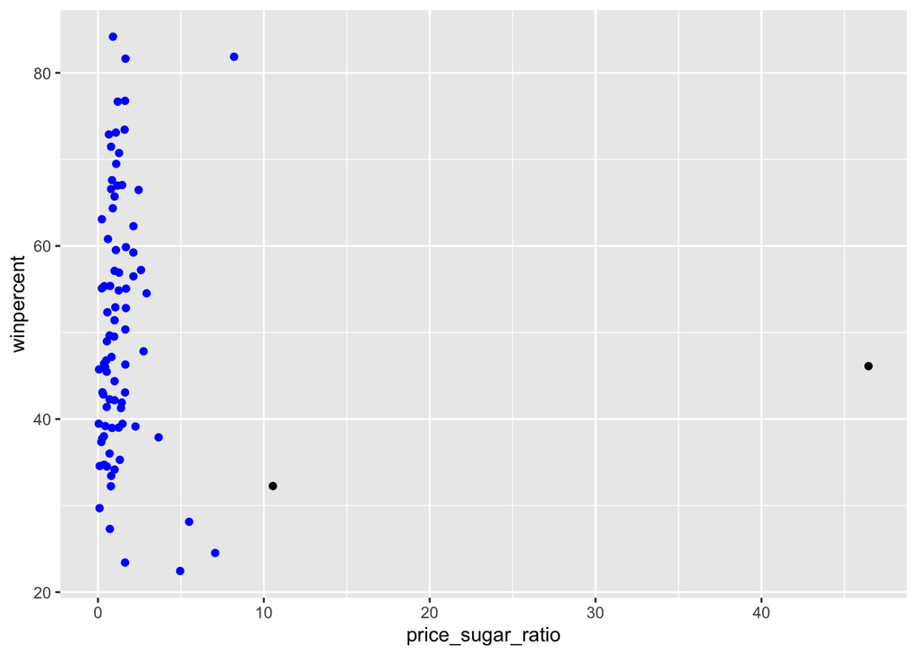

```r
# your code here
candy_df <- candy_df |>
  mutate(
    price_sugar_ratio = pricepercent / sugarpercent
  )

candy_df |>
  ggplot(aes(x = price_sugar_ratio, y = winpercent)) +
  geom_point(mapping = aes(colour = ifelse(competitorname == "One dime" | competitorname == "One quarter", "black", "blue"))) +
  scale_colour_identity()
```

## Exercise 9

Modify your plot in Exercise 8 to facet by whether a candy is bar-shaped. Have the color reflect whether the candy is fruity or not. The plot must include x and y labels along with a title. How do these plots compare to each other?

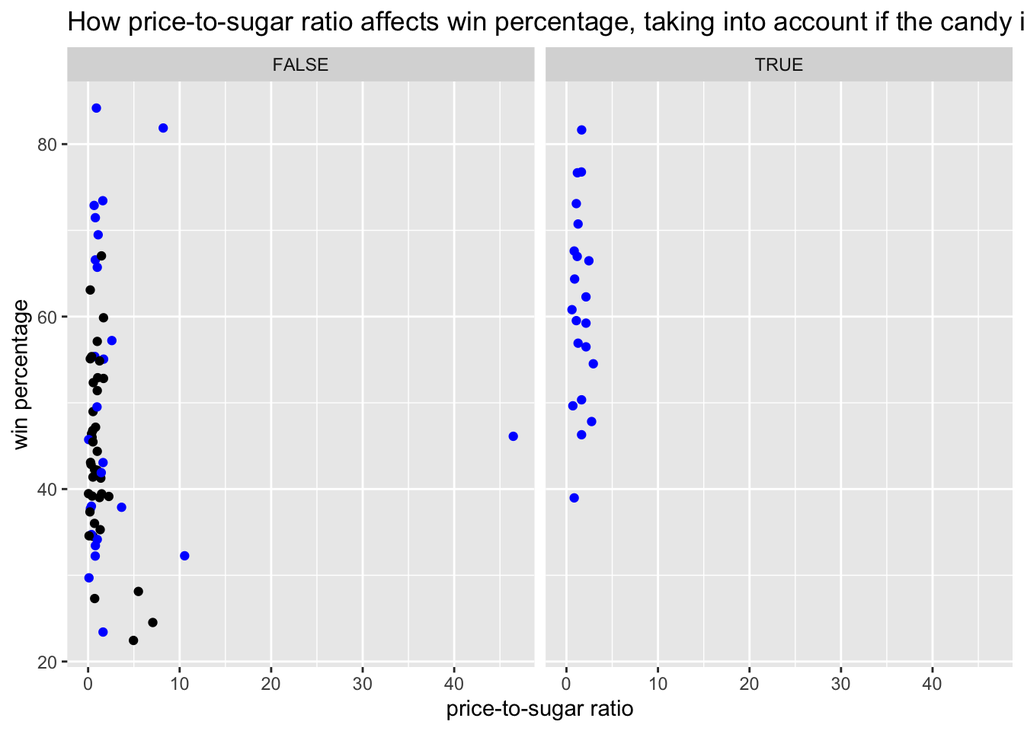

```r
# your code here
candy_df |>
  ggplot(aes(x = price_sugar_ratio, y = winpercent)) +
  geom_point(mapping = aes(colour = ifelse(fruity == TRUE, "black", "blue"))) +
  facet_wrap(~ bar) +
  scale_colour_identity() +
  labs(
    x = "price-to-sugar ratio",
    y = "win percentage",
    title = "How price-to-sugar ratio affects win percentage, taking into account if the candy is fruity and in bar form"
  )
```

# Take a sad plot and make it better!

```r
staff <- read_csv("data/instructional-staff.csv")
```

## Exercise 1

What is the difference between *wide format* data and *long format* data?

wide format data may have names/ values of variables as columns, whereas long format may have multiple entries invovling the same name or value.

Is the format `staff` data *wide* or *long*?

It is wide

How many observations are there in the data set?

There are 5 observations in the data set

## Exercise 2

```r
## Uncomment and complete the following code

staff_long <- staff %>%
 pivot_longer(
    cols = -faculty_type,
    names_to = "year",
    values_to = "percent"
    )
```

## Exercise 3

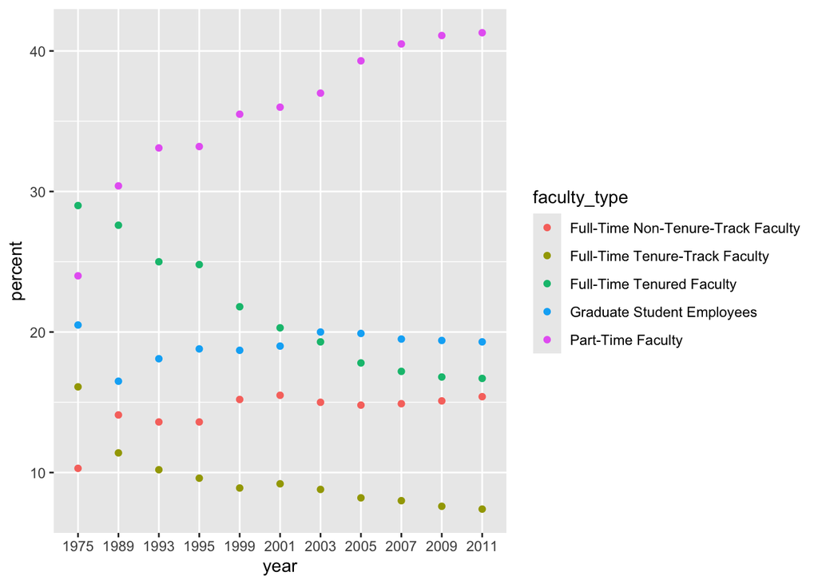

```r
# Write your code for Exercise 3 here
staff_long |>
  ggplot(aes( x = year, y = percent, color = faculty_type)) +
  geom_point()
```

## Exercise 4

```
## `geom_line()`: Each group consists of only one observation.
## ℹ Do you need to adjust the group aesthetic?
```

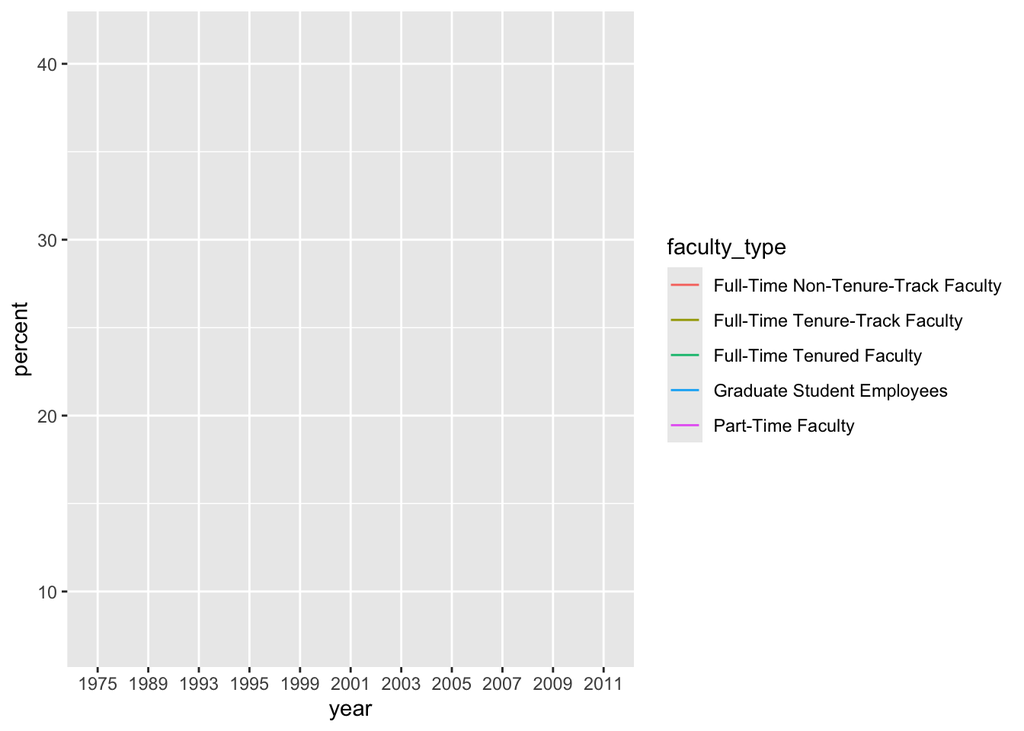

```r
# Write your code for Exercise 4 here
staff_long |>
  ggplot(aes( x = year, y = percent, color = faculty_type)) +
  geom_line()
```

## Exercise 5

```r
## Uncomment and complete the following code

staff_long <- staff_long %>%
 mutate(year = as.numeric(year))

staff_long
```

```
## # A tibble: 55 × 3
##    faculty_type               year percent
##    <chr>                     <dbl>   <dbl>
##  1 Full-Time Tenured Faculty  1975    29
##  2 Full-Time Tenured Faculty  1989    27.6
##  3 Full-Time Tenured Faculty  1993    25
##  4 Full-Time Tenured Faculty  1995    24.8
##  5 Full-Time Tenured Faculty  1999    21.8
##  6 Full-Time Tenured Faculty  2001    20.3
##  7 Full-Time Tenured Faculty  2003    19.3
##  8 Full-Time Tenured Faculty  2005    17.8
##  9 Full-Time Tenured Faculty  2007    17.2
## 10 Full-Time Tenured Faculty  2009    16.8
## # ℹ 45 more rows
```

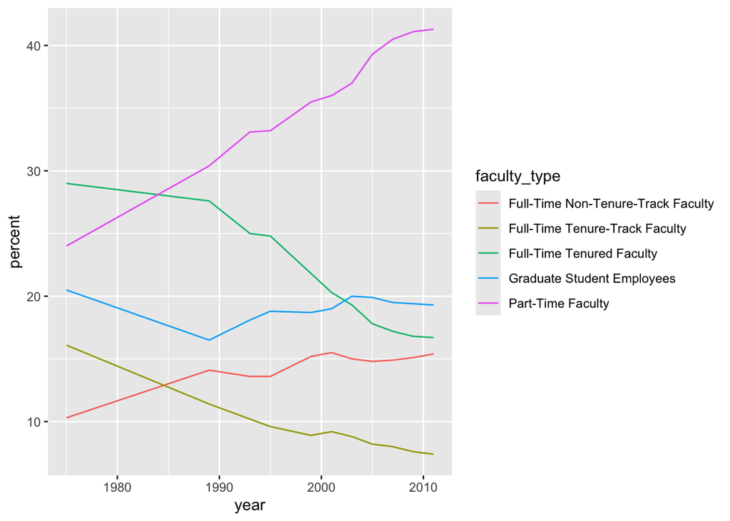

```r
# Write your code for Exercise 5 here
staff_long |>
  ggplot(aes( x = year, y = percent, color = faculty_type)) +
  geom_line()
```

## Exercise 6

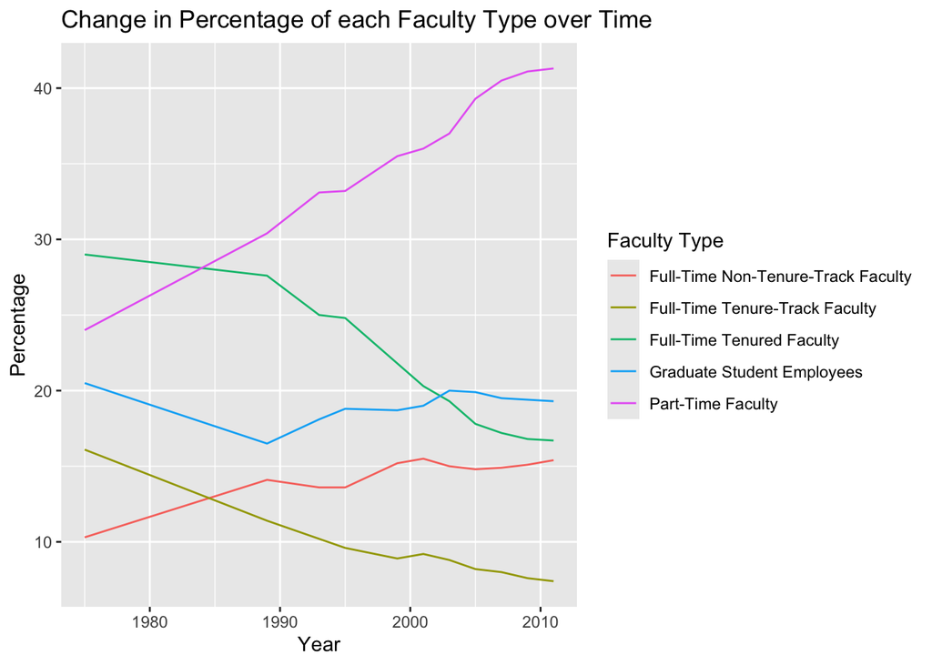

```r
# Write your code for Exercise 6 here
staff_long |>
  ggplot(aes( x = year, y = percent, color = faculty_type)) +
  geom_line() +
  labs(
    x = "Year",
    y = "Percentage",
    colour = "Faculty Type",
    title = "Change in Percentage of each Faculty Type over Time"
  )
```

## Exercise 7

*Write below your ideas for adapting the line plot*

- Only highlight the part-time faculty line, others same colour
- Add a pattern on the line

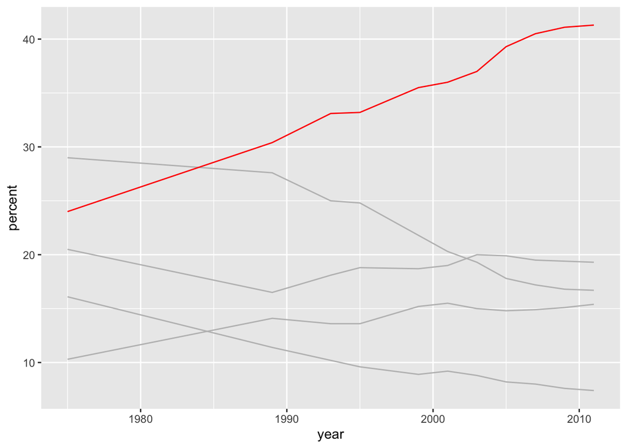

```r
# Write your code for Exercise 7 here, based on one of your ideas

#graph 1
staff_long |>
  ggplot(aes(x = year, y = percent, group = faculty_type, colour = ifelse(faculty_type == "Part-Time Faculty", "red","grey"))) +
  geom_line() +
  scale_colour_identity()
```

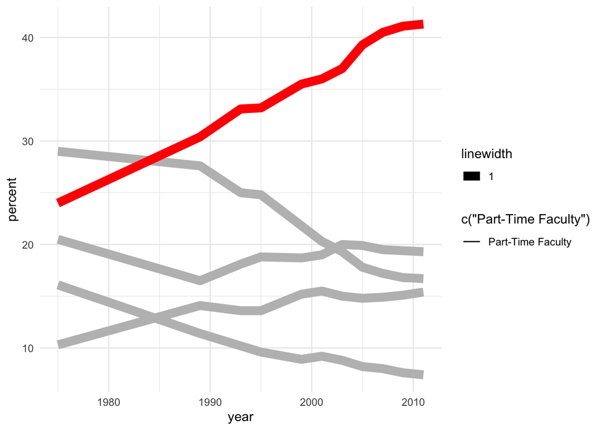

```r
#graph 2 - add pattern
library(ggpattern)

staff_long |>
  ggplot(aes(x = year, y = percent, group = faculty_type, colour = ifelse(faculty_type == "Part-Time Faculty", "red", "grey"))) +
  geom_line(aes(linetype = c("Part-Time Faculty"), linewidth = 1)) +
  theme_minimal() +
  scale_colour_identity()
```